# Notebook

# LABORATRIO 1 ## INVERSIÓN DE CAPITAL https://github.com/andres1999iteso/Lab-1-MYST.git ### EQUIPO: #### Carolina Barba Anaya Expediente: if720071 Usuario git: Carolina1002 #### Andrés Ramírez Villanueva Expediente: if726061 Usuario git: andres1999iteso

## LIBRERÍAS UTILIZADAS

- **Pandas:** Es una librería de Python especializada en el manejo y análisis de estructuras de datos https://aprendeconalf.es/docencia/python/manual/pandas/ - **Numpy:** Es una librería de Python especializada en el cálculo numérico y el análisis de datos, especialmente para un gran volumen de datos https://aprendeconalf.es/docencia/python/manual/numpy/ - **Yfinance:** Ayuda a descargar datos del mercado desde la API de Yahoo Finance https://pypi.org/project/yfinance/ - **Matplotlib:** Es una librería de Python especializada en la creación de gráficos en dos dimensiones https://aprendeconalf.es/docencia/python/manual/matplotlib/ - **Scipy:** Es una librería que contiene módulos para optimización, álgebra lineal, integración, interpolación, funciones especiales, procesamiento de señales e imagen, y otras tareas relacionadas con la ciencia e ingeniería https://unipython.com/scipy-funciones-principales/ - **Datetime:** Para manejar fechas en Python se suele utilizar la librería datetime que incorpora los tipos de datos date, time y datetime para representar fechas y funciones para manejarlas https://aprendeconalf.es/docencia/python/manual/datetime/

```python
import warnings
import main
import data
import pandas as pd
import visualizations
warnings.filterwarnings("ignore")
```

## INTRODUCCION

Al hacer un portafolio de inversión, lo que siempre se busca es tener el mayor rendimiento posible y un buen manejo del riesgo, existen varias estrategias de inversión y siempre es importante conocer los riesgos y los beneficios que cada uno de estos métodos nos aportan, la inversión activa y la inversión pasiva son dos métodos muy debatidos desde hace varias décadas.

Este debate se da por los objetivos que cada inversor esta buscando, los inversores activos intentan superar la rentabilidad de un índice de referencia específico, mientras que los inversores pasivos aceptan la rentabilidad del mercado siguiendo un índice específico.

Ambas estrategias tienen ventajas y desventajas, que dependiendo el perfil del inversionista, ayudarán a tomar la estrategia que más se adapte a sus necesidades.

**Inversión activa:**

Ventajas

- La oportunidad de superar al mercado
- La flexibilidad que se tiene, ya que se puede invertir con mayor libertad ya que no están vinculados a un índice, y se puede adaptar a las necesidades de cualquier cliente
- Gestión del riesgo: se pueden minimizar las pérdidas potenciales evitando determinados sectores, regiones, etc.

Desventajas

- La rentabilidad depende de la habilidad del inversionista, ya que existe el riesgo de invertir en un fondo que obtenga resultados desfavorables
- Costes más elevados, el manejo y las comisiones de la gestión de las inversiones son más elevadas
- Riesgo del hombre clave: si la persona que maneja el fondo tiene algún accidente y se tiene que cambiar de gestor, existe algún riesgo de que esta persona no sea igual de eficiente al manejar el portafolio

**Inversión pasiva:**

Ventajas

- Se sabe lo que obtiene: ya que es poco probable que un fondo pasivo obtenga un rendimiento inferior al índice de mercado por un margen significativo.
- Bajo coste: las comisiones de manejo de está estrategia son menores que la activa
- Estos fondos pasivos también pueden ofrecer una forma rápida y sencilla de acceder a un mercado
- Sin riesgo de hombre clave

Desventajas

- Costes ocultos:se subestiman los costes para manejar esta estrategia, ya que a veces el coste para rebalancear es elevado
- Las decisiones de asignación de activos no pueden ser pasivas: ya que al manejar esto es fundamental que se aprovechen las oportunidades de mercado a corto plazo, lo que implica decisiones activas
- No hay posibilidad de superar la rentabilidad
- Falta de elección, ya que el inversor está obligado a aceptar un índice, independientemente de cómo esté construido y de la calidad de las participaciones subyacentes de ese índice

Decidir que estrategía es mejor no es sencillo, y teniendo en cuenta las ventajas y desventajas de ambas, se debe establecer que es lo más apropiado para el inversionista, en base a sus criterios y objetivos.

## OBJETIVOS

- Simular una inversión de un millón de pesos - Utilizar ambas estrategías de inversión: activa y pasiva - Comparar la evolución del capital de ambas estratégias - Y comparar sus medidas de desempeño para elegir el método que nos de mejores rendimientos - Con base a la práctica, definir que estrategía de inversíon es más eficiente

## DATOS

Para el desarrollo del proyecto en cuestión fue necesario el manipular información proveniente de dos fuentes, la primera es la estructura del ETF iShares NAFTRAC de Blackrock, esto para analizar la tendencia que había en la presencia de diversas empresas presentes en dicho instrumento y a su vez extraerlas para más adelante estructurar nuestros portafolios. En dicho archivo no sólo podíamos observar las acciones que lo conformaban sino también otros datos relacionados al instrumento.

A continuación se muestra un breve extracto de como son estos formatos.

```python
data.NAFTRAC_20210129.head(3)
```

|  | Ticker | Nombre | Clase de activo | Peso (%) | Precio | Acciones | Valor de mercado | Valor nominal | Sector | Unnamed: 9 | ISIN | Bolsa de valores | Ubicación | Moneda | Mercado de divisas | Tipo de Cambio |
| --- | --- | --- | --- | --- | --- | --- | --- | --- | --- | --- | --- | --- | --- | --- | --- | --- |
| 0 | AMXL | AMERICA MOVIL L | Equity | 12.29 | 13.67 | 471,480,741.00 | 6,445,141,729.47 | 6,445,141,729.47 | Comunicación | 2667470 | MXP001691213 | Bolsa Mexicana De Valores | México | MXN | MXN | 1.0 |
| 1 | WALMEX* | WALMART DE MEXICO V | Equity | 11.14 | 58.35 | 100,125,728.00 | 5,842,336,228.80 | 5,842,336,228.80 | Productos básicos de consumo | BW1YVH8 | MX01WA000038 | Bolsa Mexicana De Valores | México | MXN | MXN | 1.0 |
| 2 | GMEXICOB | GRUPO MEXICO B | Equity | 10.57 | 87.84 | 63,111,774.00 | 5,543,738,228.16 | 5,543,738,228.16 | Materiales | 2643674 | MXP370841019 | Bolsa Mexicana De Valores | México | MXN | MXN | 1.0 |

Como podemos observar, estos datos no sólo contienen la información de nuestro interés, por lo tanto fue necesario el extraerla y manipularla en otras variables.

Una vez cargada los archivos necesarios y posterior a su manipulación, nos percatamos de que había 32 nombres de empresas que se repetían en todos los periodos, sin embargo en estas estaba presente una etiqueta que representaba el "cash" que se tenía dentro del ETF, por lo tanto optamos por retirarlo, quedando así sólo 31 empresas.

Este es un extracto de las etiquetas que se repetían en todos los periodos.

```python
main.final.head(5)
```

|  | Ticker |
| --- | --- |
| 0 | AMXL |
| 1 | GFINBURO |
| 2 | MXN |
| 3 | ALSEA* |
| 4 | LIVEPOLC.1 |

```python
pd.DataFrame(main.nuevo["Ticker"].head(5))
```

|  | Ticker |
| --- | --- |
| 16 | AC* |
| 19 | ALFAA |
| 30 | ALSEA* |
| 0 | AMXL |
| 9 | ASURB |

De igual forma y para mantener cierta estructura dentro de nuestro proyecto, optamos por acomodar las acciones alfabéticamente. Por otro lado, es importante mencionar que dichos reportes de blackrock fueron de suma importancia no sólo por lo mencionado anteriormente sino que también porque el primer reporte sirvión para extraer las ponderaciones iniciales de lo que es el portafolio de inversión pasiva. Aquí podemos ver algunos pesos de los activos.

```python
main.tabla_temporal.iloc[:,0:2].head(5)
```

|  | Ticker | Pesos |
| --- | --- | --- |
| 16 | AC.MX | 0.0155 |
| 13 | ALFAA.MX | 0.0136 |
| 2 | ALSEA.MX | 0.0044 |
| 0 | AMXL.MX | 0.1229 |
| 25 | ASURB.MX | 0.0243 |

## PROCESOS

### Creación y simulación portafolio pasivo

En esta parte del proyecto simplemente tomamos las ponderaciones del primer periodo del ETF con sus respectivas acciones y simulamos una inversión de capital sin hacer rebalanceos durante todo el periodo evaluado, sólo tuvimos que pagar comisiones al inicio, en lo posterior dejamos "madurar" el portafolio para su posterior comparación, aquí una muestra gráfica de como fue cambiando en el tiempo en sus rendimientos.

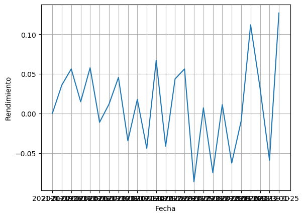

```python
visualizations.fig0
```

Por otro lado, aquí tenemos en valor del portafolio.

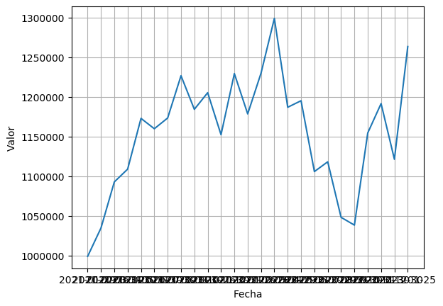

```python
visualizations.fig1
```

A su vez, aquí tenemos un dataframe con la evolución del mismo de forma más detallada.

```python
main.df_pasiva.head(2)
```

|  | Date | Valor portafolio | Rendimiento | Rendimiento acumulado |
| --- | --- | --- | --- | --- |
| 0 | 2021-01-29 | 998834.796807 | 0 | 0 |
| 1 | 2021-02-26 | 1034613.562956 | 0.035821 | 0.035821 |

```python
main.df_pasiva.tail(2)
```

|  | Date | Valor portafolio | Rendimiento | Rendimiento acumulado |
| --- | --- | --- | --- | --- |
| 23 | 2022-12-30 | 1121300.598752 | -0.059007 | 0.145131 |
| 24 | 2023-01-25 | 1263578.487866 | 0.126886 | 0.272018 |

### Cálculo poderaciones portafolio EMV

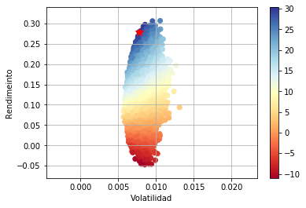

Una vez hecho esto, obtuvimos las ponderaciones para nuestro portafolio activo.

```python
main.ponderaciones_montecarlo
```

|  | AC.MX | ALFAA.MX | ALSEA.MX | AMXL.MX | ASURB.MX | BBAJIOO.MX | BIMBOA.MX | BOLSAA.MX | CEMEXCPO.MX | CUERVO.MX | ... | LIVEPOLC-1.MX | MEGACPO.MX | OMAB.MX | ORBIA.MX | PE&OLES.MX | PINFRA.MX | Q.MX | TLEVISACPO.MX | VESTA.MX | WALMEX.MX |
| --- | --- | --- | --- | --- | --- | --- | --- | --- | --- | --- | --- | --- | --- | --- | --- | --- | --- | --- | --- | --- | --- |
| 761666 | 0.025693 | 0.003322 | 0.114773 | 0.184324 | 0.041551 | 0.064558 | 0.06039 | 0.01019 | 0.030012 | 0.034171 | ... | 0.034371 | 0.003193 | 0.016562 | 0.004354 | 0.008502 | 0.037787 | 0.008534 | 0.008891 | 0.008126 | 0.022529 |

1 rows × 31 columns

### Cálculo y simulación portafolio activo

Para nuestro portafolio activo tuvimos que usar un periodo de analisis de las acciones que fue el primer año, más adelante hicimos rebalanceos cada mes siguiendo las instrucciones de trading descritas en la plataforma. Obtuvimos los siguientes rendimientos.

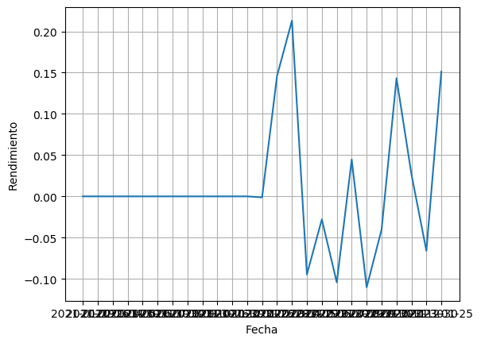

```python
visualizations.fig2
```

A continuación, una muestra gráfica de la evolución del portafolio en el tiempo.

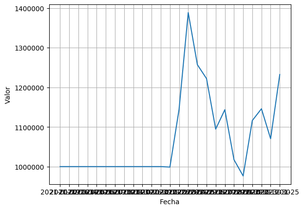

```python
visualizations.fig3
```

En este dataframe se observa un resumen numérico de lo descrito en las gráficas anteriores.

```python
main.df_activa.tail(5)
```

|  | Date | Valor portafolio | Rendimiento | Rendimiento acumulado |
| --- | --- | --- | --- | --- |
| 20 | 2022-09-30 | 976433 | -0.040247 | 0.025201 |
| 21 | 2022-10-31 | 1116185 | 0.143125 | 0.168326 |
| 22 | 2022-11-30 | 1145899 | 0.026621 | 0.194947 |
| 23 | 2022-12-30 | 1070333 | -0.065945 | 0.129002 |
| 24 | 2023-01-25 | 1232269 | 0.151295 | 0.280297 |

Aunado a lo anterior, aquí se muestra una tabla con la evolcuión de los movimientos en el portafolio activo, es importante mencionar que la parte con 0s es el periodo tomado para análisis y construcción del portafolio EMV.

```python
main.df_operaciones
```

|  | Date | Titulos totales | Titulos compra | Titulos venta | Comisión | Comisión acum |
| --- | --- | --- | --- | --- | --- | --- |
| 0 | 2021-01-29 | 0 | 0 | 0 | 0.000000 | 0.000000 |
| 1 | 2021-02-26 | 0 | 0 | 0 | 0.000000 | 0.000000 |
| 2 | 2021-03-31 | 0 | 0 | 0 | 0.000000 | 0.000000 |
| 3 | 2021-04-30 | 0 | 0 | 0 | 0.000000 | 0.000000 |
| 4 | 2021-05-31 | 0 | 0 | 0 | 0.000000 | 0.000000 |
| 5 | 2021-06-30 | 0 | 0 | 0 | 0.000000 | 0.000000 |
| 6 | 2021-07-30 | 0 | 0 | 0 | 0.000000 | 0.000000 |
| 7 | 2021-08-31 | 0 | 0 | 0 | 0.000000 | 0.000000 |
| 8 | 2021-09-30 | 0 | 0 | 0 | 0.000000 | 0.000000 |
| 9 | 2021-10-26 | 0 | 0 | 0 | 0.000000 | 0.000000 |
| 10 | 2021-11-30 | 0 | 0 | 0 | 0.000000 | 0.000000 |
| 11 | 2021-12-31 | 0 | 0 | 0 | 0.000000 | 0.000000 |
| 12 | 2022-01-26 | 23639 | 23639 | 0 | 1207.000000 | 1207.000000 |
| 13 | 2022-02-28 | 23553 | 254 | 340 | 76.027504 | 1283.027466 |
| 14 | 2022-03-31 | 23816 | 425 | 162 | 139.186142 | 1422.213623 |
| 15 | 2022-04-29 | 23225 | 0 | 591 | 35.364449 | 1457.578125 |
| 16 | 2022-05-31 | 22823 | 86 | 488 | 39.887806 | 1497.465942 |
| 17 | 2022-06-30 | 22264 | 6 | 565 | 31.264130 | 1528.730103 |
| 18 | 2022-07-29 | 22195 | 241 | 310 | 38.522518 | 1567.252563 |
| 19 | 2022-08-31 | 21648 | 3 | 550 | 28.411135 | 1595.663696 |
| 20 | 2022-09-30 | 21201 | 15 | 462 | 23.542730 | 1619.206421 |
| 21 | 2022-10-31 | 21358 | 183 | 26 | 33.303024 | 1652.509399 |
| 22 | 2022-11-30 | 21031 | 45 | 372 | 35.476524 | 1687.985962 |
| 23 | 2022-12-30 | 20533 | 14 | 512 | 31.307844 | 1719.293823 |
| 24 | 2023-01-25 | 20633 | 118 | 18 | 27.115923 | 1746.409790 |

Por último, en la parte de conclusiones hablaremos un poco más de la comparativa entre portafolios.

## CONCLUSIÓN

```python
main.df_medidas
```

|  | Medida | Descripción | Inv activa | Inv pasiva |
| --- | --- | --- | --- | --- |
| 0 | rend_m | Rendimiento Promedio Mensual | 0.020021 | 0.010881 |
| 1 | rend_c | Rendimiento mensual acumulado | 0.280297 | 0.272018 |
| 2 | sharpe | Sharpe Ratio | 0.155213 | 0.132956 |

#### Carolina

Después de hacer la simulación con ambas estrategias, me pude dar cuenta que los rendimientos fueron muy similares, esto es debido a que en ambos se utilizan prácticamente las mismas acciones, sin embargo, para decidir la mejor opción de inversión debemos tomar en cuenta los objetivos del cliente, al tomar una inversión pasiva existe menor riesgo pero el rendimiento nunca podrá superar el índice que estamos tomando de referencia, por otro lado si elegimos la inversión activa existe un riesgo mayor, ya que o podemos tener mayores rendimientos o podemos perder más que en la pasiva, esto tiene que ver con nuestra habilidad de análisis para la compra y venta de las acciones. En este ejemplo, la inversión activa tuvo un mejor rendimiento acumulado que la pasiva, en mi caso mi perfil como inversionista es averso al riesgo, y al ver que los rendimientos son similares, me decidiría por la inversión pasiva.